# Session 10: Data Science Capstone Project

# 5 Fit a tree model

Next I fit a tree model using the same subset of features. Again you can (and should) add more variables and tune the parameter of your tree to find a better fit.

Compare the performance of the linear regression model with the tree model; which one performs better? Why do you think that is the case?

```r
#For the tree model, we will use the same features as for the first lm model (the
#one without any polynomials and interactions), and replacing district with
#latitude and longitude, as these work much better with tree-based models for
#determining geographical price effects.

#we will tune the cp parameter to pick the optimal tree model
set.seed(1234)
model1_tree <- train(
  log(price) ~ property_type + whether_old_or_new + freehold_or_leasehold + current_energy_rating + total_floor_area + co2_emissions_potential + energy_consumption_potential + tenure + population + altitude + factor(london_zone) + water_company + average_income + type_of_closest_station + num_tube_lines + num_rail_lines + num_light_rail_lines + distance_to_station + latitude + longitude,
  train_data%>%filter(is.na(population)==FALSE),
  method = "rpart",
  trControl = control,
  metric="RMSE",
  tuneLength=10)
print(model1_tree)
```

```
## CART
##
## 10446 samples
##    20 predictor
##
## No pre-processing
## Resampling: Cross-Validated (5 fold)
## Summary of sample sizes: 8357, 8357, 8357, 8356, 8357
## Resampling results across tuning parameters:
##
##   cp           RMSE       Rsquared   MAE
##   0.009957106  0.3461711  0.5977096  0.2585919
##   0.010579079  0.3461711  0.5977096  0.2585919
##   0.014337000  0.3562673  0.5738743  0.2686294
##   0.014428568  0.3575000  0.5709122  0.2699667
##   0.019597099  0.3695726  0.5411039  0.2796233
##   0.019825722  0.3730085  0.5326956  0.2822666
##   0.021681154  0.3791666  0.5170551  0.2876771
##   0.065481636  0.4047652  0.4491527  0.3059931
##   0.083269339  0.4281063  0.3836480  0.3219176
##   0.359827287  0.4830584  0.3451652  0.3635525
##
## RMSE was used to select the optimal model using the smallest value.
## The final value used for the model was cp = 0.01057908.
```

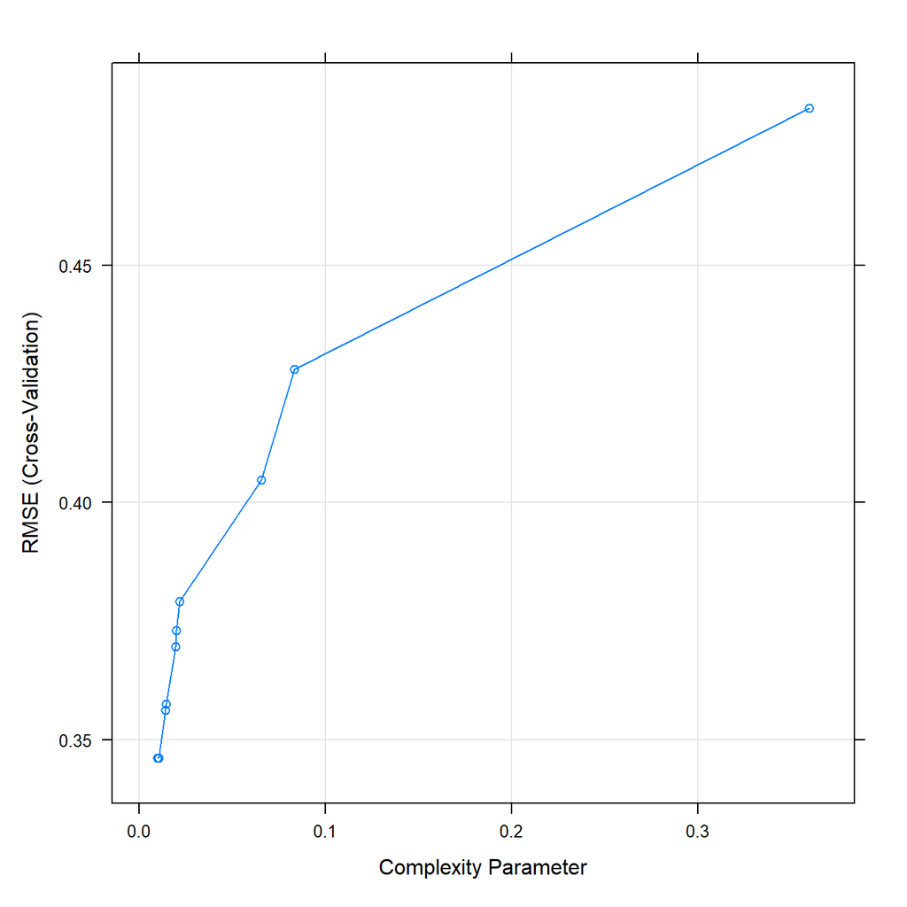

```r
plot(model1_tree)
```

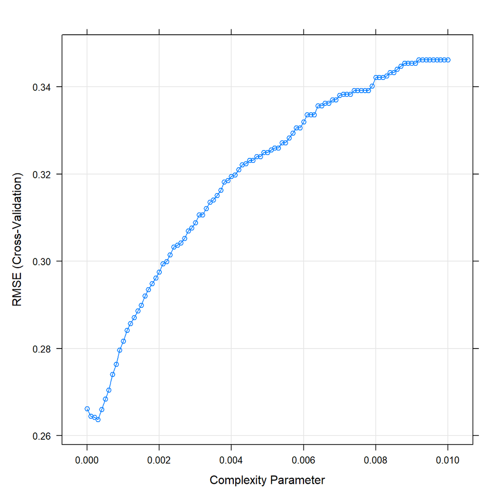

```r
#clearly the optimal cp is below 0.01


Grid <- expand.grid(cp = seq(0, 0.01, by=0.0001))

set.seed(1234)
model2_tree <- train(
  log(price) ~ property_type+whether_old_or_new+freehold_or_leasehold+current_energy_rating+total_floor_area+ co2_emissions_potential+energy_consumption_potential+tenure+population+altitude+factor(london_zone)+water_company+average_income+latitude+longitude+type_of_closest_station+num_tube_lines+num_rail_lines+num_light_rail_lines+distance_to_station,
  train_data%>%filter(is.na(population)==FALSE),
  method = "rpart",
  trControl = control,
  metric="RMSE",
  tuneGrid=Grid)
plot(model2_tree)
```

```r
print(model2_tree)
```

```
## CART
##
## 10446 samples
##    20 predictor
##
## No pre-processing
## Resampling: Cross-Validated (5 fold)
## Summary of sample sizes: 8357, 8357, 8357, 8356, 8357
## Resampling results across tuning parameters:
##
##   cp      RMSE       Rsquared   MAE
##   0.0000  0.2661724  0.7667349  0.1940875
##   0.0001  0.2644980  0.7685793  0.1917598
##   0.0002  0.2642474  0.7678102  0.1922756
##   0.0003  0.2637303  0.7678223  0.1925308
##   0.0004  0.2660588  0.7634421  0.1942969
##   0.0005  0.2684233  0.7590021  0.1961508
##   0.0006  0.2704835  0.7551708  0.1980892
##   0.0007  0.2740857  0.7485730  0.2002054
##   0.0008  0.2764230  0.7440958  0.2021167
##   0.0009  0.2796353  0.7379608  0.2044180
##   0.0010  0.2816707  0.7340224  0.2061022
##   0.0011  0.2842123  0.7292082  0.2083022
##   0.0012  0.2857467  0.7263094  0.2094761
##   0.0013  0.2870947  0.7235708  0.2106943
##   0.0014  0.2886203  0.7205716  0.2118809
##   0.0015  0.2899084  0.7180487  0.2126925
##   0.0016  0.2920311  0.7137585  0.2148718
##   0.0017  0.2935199  0.7107417  0.2158746
##   0.0018  0.2949144  0.7079974  0.2169442
##   0.0019  0.2961361  0.7054905  0.2182203
##   0.0020  0.2975131  0.7028098  0.2188263
##   0.0021  0.2994084  0.6990011  0.2202433
##   0.0022  0.2999799  0.6977920  0.2204822
##   0.0023  0.3014471  0.6948040  0.2217051
##   0.0024  0.3032646  0.6910754  0.2230909
##   0.0025  0.3037372  0.6901540  0.2235737
##   0.0026  0.3041901  0.6892541  0.2241150
##   0.0027  0.3052733  0.6870734  0.2245660
##   0.0028  0.3069661  0.6836262  0.2259182
```

[output cut: 60 more lines]

```
##   0.0089  0.3454213  0.5994734  0.2578418
##   0.0090  0.3454213  0.5994734  0.2578418
##   0.0091  0.3454213  0.5994734  0.2578418
##   0.0092  0.3461711  0.5977096  0.2585919
##   0.0093  0.3461711  0.5977096  0.2585919
##   0.0094  0.3461711  0.5977096  0.2585919
##   0.0095  0.3461711  0.5977096  0.2585919
##   0.0096  0.3461711  0.5977096  0.2585919
##   0.0097  0.3461711  0.5977096  0.2585919
##   0.0098  0.3461711  0.5977096  0.2585919
##   0.0099  0.3461711  0.5977096  0.2585919
##   0.0100  0.3461711  0.5977096  0.2585919
##
## RMSE was used to select the optimal model using the smallest value.
## The final value used for the model was cp = 3e-04.
```

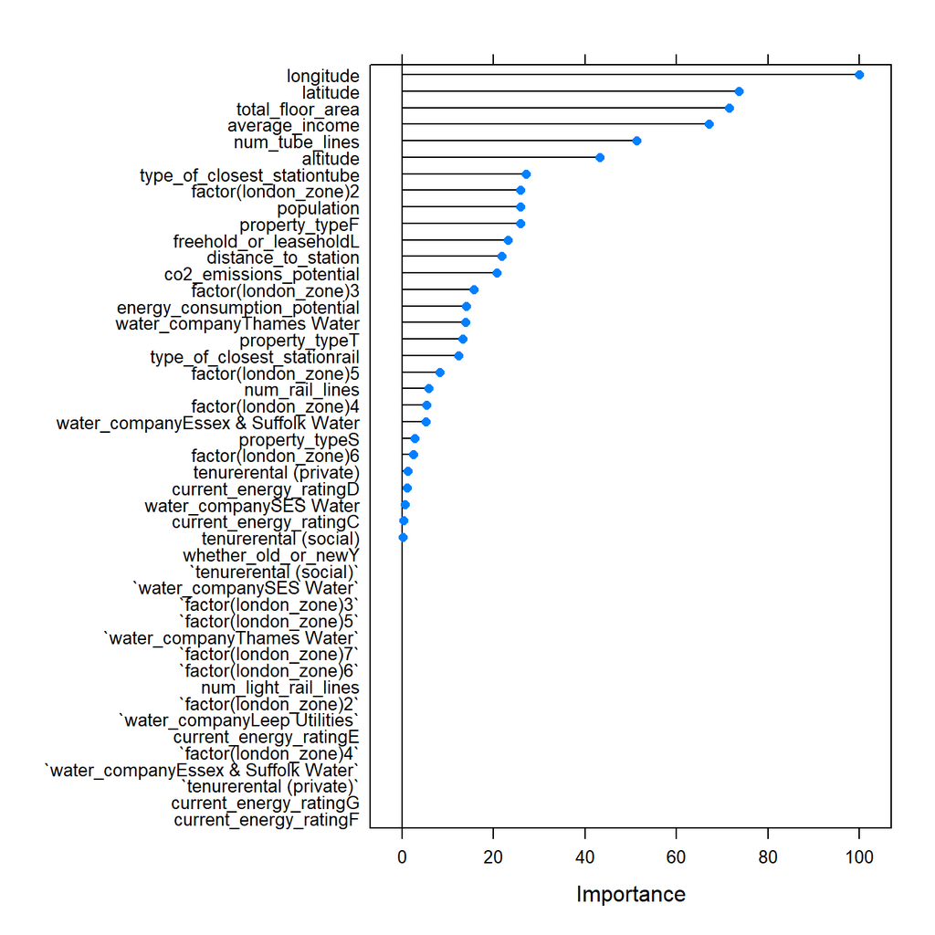

```r
#model2_tree: RMSE=0.2637303, R2=0.7678223, cp=0.0003

#visualizing variable importance
importance <- varImp(model2_tree, scale=TRUE)
plot(importance)
```

```r
#latitude and longitude are clearly very important for tree-based models
```

```r
# We can predict the testing values
test_data_tree<-test_data%>%filter(is.na(population)==FALSE)

predictions_tree <- predict(model2_tree,test_data_tree)

tree_results<-data.frame(Method="Trees", RMSE = RMSE(predictions_tree, log(test_data_tree$price)),
                            Rsquare = R2(predictions_tree, log(test_data_tree$price)))


tree_results
```

```
##   Method     RMSE   Rsquare
## 1  Trees 0.271072 0.7570593
```

```r
#We can predict prices for out of sample data the same way
predictions_oos_tree <- predict(model2_tree,london_house_prices_2019_out_of_sample)
```

# 6 Other algorithms

Use at least two other algorithms to predict prices. Don’t forget to tune the parameters of these algorithms. And then compare the performances of your algorithms to linear regression and trees.

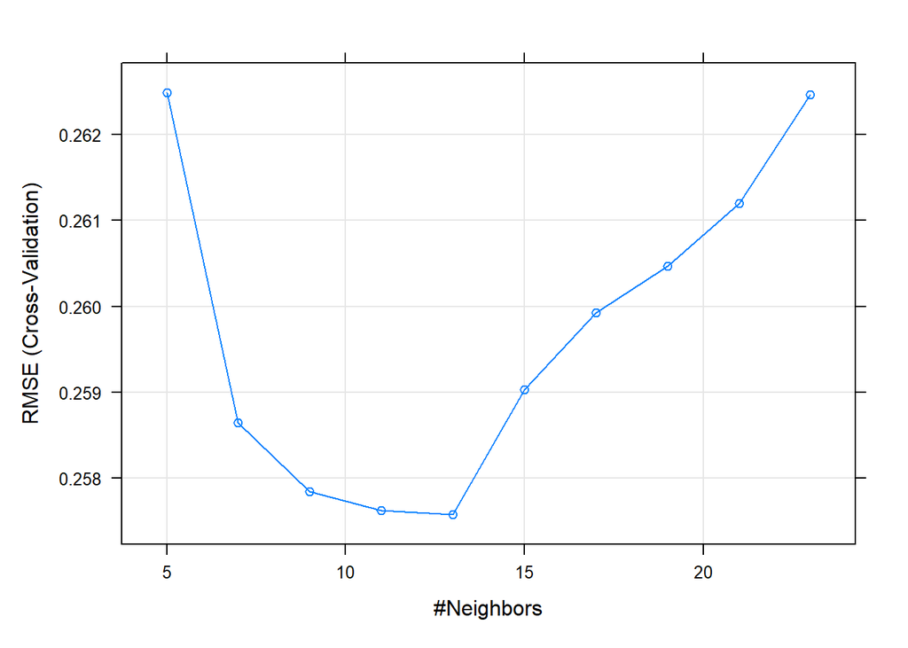

```r
#For knn, we only keep numerical variables, categorical variables with only 2
#categories as well as categorical variables with more than 2 categories that can
#be nonetheless converted to a numerical scale
train_data_knn<-train_data%>%select(price, total_floor_area, current_energy_rating, number_habitable_rooms, co2_emissions_potential, energy_consumption_potential, latitude, longitude, population, altitude, london_zone, average_income, num_tube_lines, num_light_rail_lines, num_rail_lines, distance_to_station, property_type, whether_old_or_new, freehold_or_leasehold, tenure)%>%
                                  filter(is.na(population)==FALSE)%>%
                                   mutate(current_energy_rating=case_when( current_energy_rating=="B"~1,current_energy_rating=="C"~2,current_energy_rating=="D"~3,current_energy_rating=="E"~4,current_energy_rating=="F"~5,current_energy_rating=="G"~6),property_type=case_when(property_type=="D"~1, property_type=="S"~2,property_type=="T"~3, property_type=="F"~4), tenure=case_when(tenure=="owner-occupied"~1, tenure=="rental (private)"~2, tenure=="rental (social)"~3), whether_old_or_new=case_when(whether_old_or_new=="Y"~1, whether_old_or_new=="N"~2), freehold_or_leasehold=case_when(freehold_or_leasehold=="F"~1, freehold_or_leasehold=="L"~2))


#we will tune the k parameter to pick the optimal knn model
set.seed(1234)
model1_knn <- train(log(price)~., data=train_data_knn,
                 method = "knn",
                 trControl = control,
                 measure="RMSE",
                 preProcess = c("center", "scale"),
                 tuneLength = 10)
plot(model1_knn)
```

```r
print(model1_knn)
```

```
## k-Nearest Neighbors
##
## 10446 samples
##    19 predictor
##
## Pre-processing: centered (19), scaled (19)
## Resampling: Cross-Validated (5 fold)
## Summary of sample sizes: 8357, 8357, 8357, 8356, 8357
## Resampling results across tuning parameters:
##
##   k   RMSE       Rsquared   MAE
##    5  0.2624881  0.7699168  0.1907324
##    7  0.2586475  0.7783995  0.1876957
##    9  0.2578453  0.7819175  0.1869085
##   11  0.2576215  0.7839759  0.1867371
##   13  0.2575751  0.7860665  0.1862746
##   15  0.2590281  0.7850207  0.1872647
##   17  0.2599293  0.7849190  0.1878705
##   19  0.2604709  0.7855254  0.1882330
##   21  0.2611958  0.7857676  0.1887726
##   23  0.2624588  0.7847402  0.1895477
##
## RMSE was used to select the optimal model using the smallest value.
## The final value used for the model was k = 13.
```

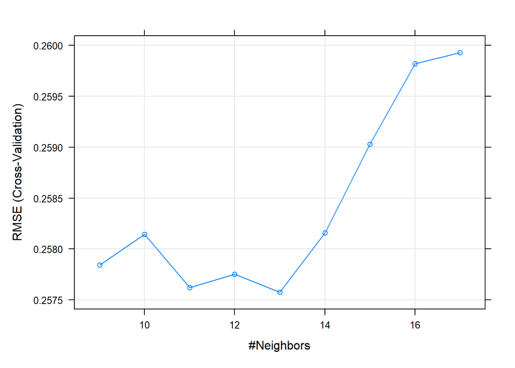

```r
#searching in the vicinity of k=13
knnGrid <-  expand.grid(k= seq(9, 17 , by = 1))
set.seed(1234)
model2_knn <- train(log(price)~., data=train_data_knn,
                 method = "knn",
                 trControl = control,
                 measure="RMSE",
                 preProcess = c("center", "scale"),
                 tuneGrid = knnGrid)
plot(model2_knn)
```

```r
print(model2_knn)
```

```
## k-Nearest Neighbors
##
## 10446 samples
##    19 predictor
##
## Pre-processing: centered (19), scaled (19)
## Resampling: Cross-Validated (5 fold)
## Summary of sample sizes: 8357, 8357, 8357, 8356, 8357
## Resampling results across tuning parameters:
##
##   k   RMSE       Rsquared   MAE
##    9  0.2578453  0.7819175  0.1869085
##   10  0.2581435  0.7821994  0.1870845
##   11  0.2576215  0.7839759  0.1867371
##   12  0.2577529  0.7846538  0.1867315
##   13  0.2575751  0.7860665  0.1862746
##   14  0.2581609  0.7858186  0.1866165
##   15  0.2590281  0.7850207  0.1872647
##   16  0.2598190  0.7843568  0.1878377
##   17  0.2599293  0.7849190  0.1878705
##
## RMSE was used to select the optimal model using the smallest value.
## The final value used for the model was k = 13.
```

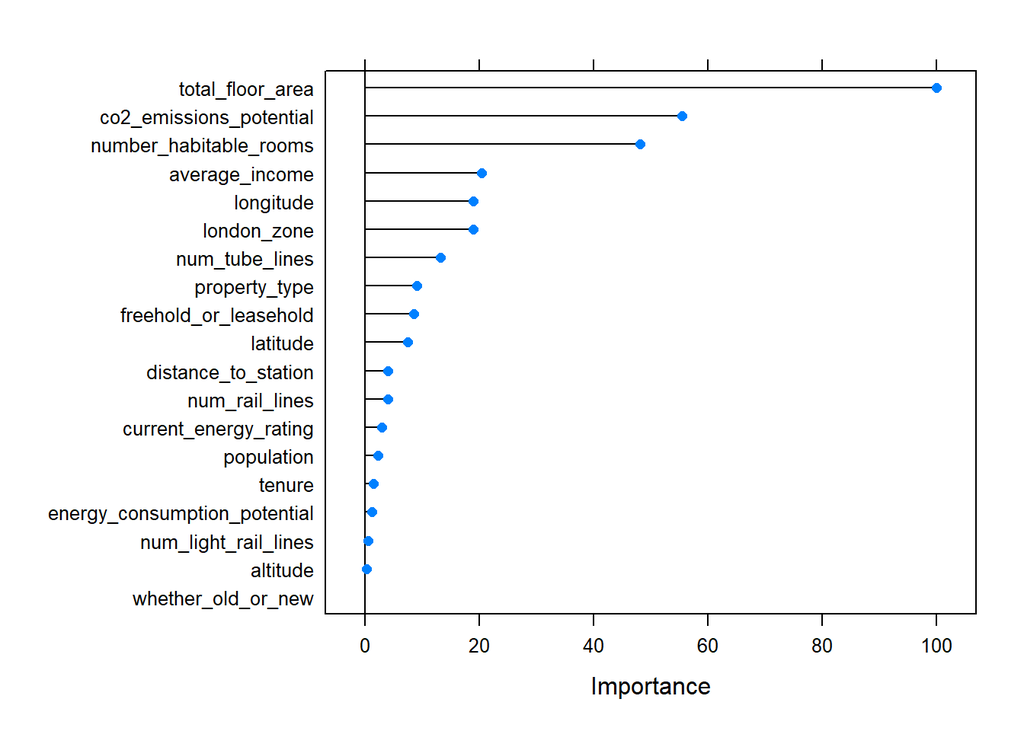

```r
#model2_knn: RMSE=0.2575751, R2=0.7860665, k=13

importance <- varImp(model2_knn, scale=TRUE)
plot(importance)
```

```r
# We can predict the testing values
test_data_knn<-test_data%>%select(total_floor_area, current_energy_rating, number_habitable_rooms, co2_emissions_potential, energy_consumption_potential, latitude, longitude, population, altitude, london_zone, average_income, price, num_tube_lines, num_light_rail_lines, num_rail_lines, distance_to_station, property_type, whether_old_or_new, freehold_or_leasehold, tenure)%>%
                                  filter(is.na(population)==FALSE)%>%
                                   mutate(current_energy_rating=case_when( current_energy_rating=="B"~1,current_energy_rating=="C"~2,current_energy_rating=="D"~3,current_energy_rating=="E"~4,current_energy_rating=="F"~5,current_energy_rating=="G"~6),property_type=case_when(property_type=="D"~1, property_type=="S"~2,property_type=="T"~3, property_type=="F"~4), tenure=case_when(tenure=="owner-occupied"~1, tenure=="rental (private)"~2, tenure=="rental (social)"~3), whether_old_or_new=case_when(whether_old_or_new=="Y"~1, whether_old_or_new=="N"~2), freehold_or_leasehold=case_when(freehold_or_leasehold=="F"~1, freehold_or_leasehold=="L"~2))


predictions_knn <- predict(model2_knn,test_data_knn)

knn_results<-data.frame(Method="KNN", RMSE = RMSE(predictions_knn, log(test_data_knn$price)),
                            Rsquare = R2(predictions_knn, log(test_data_knn$price)))


knn_results
```

```
##   Method      RMSE   Rsquare
## 1    KNN 0.2639372 0.7770131
```

```r
#We can predict prices for out of sample data the same way
predictions_oos_knn <- predict(model2_knn,london_house_prices_2019_out_of_sample%>%
                                   mutate(current_energy_rating=case_when( current_energy_rating=="B"~1,current_energy_rating=="C"~2,current_energy_rating=="D"~3,current_energy_rating=="E"~4,current_energy_rating=="F"~5,current_energy_rating=="G"~6),property_type=case_when(property_type=="D"~1, property_type=="S"~2,property_type=="T"~3, property_type=="F"~4), tenure=case_when(tenure=="owner-occupied"~1, tenure=="rental (private)"~2, tenure=="rental (social)"~3), whether_old_or_new=case_when(whether_old_or_new=="Y"~1, whether_old_or_new=="N"~2), freehold_or_leasehold=case_when(freehold_or_leasehold=="F"~1, freehold_or_leasehold=="L"~2)))
```

```r
#since random forests is a tree-based ensemble method, we will use the same features
#as in the tree model

#looking for best mtry for min node size = 10
set.seed(1234)
model1_rf <- train(
  log(price) ~ property_type + whether_old_or_new + freehold_or_leasehold + current_energy_rating + total_floor_area + co2_emissions_potential + energy_consumption_potential + tenure + population + altitude + factor(london_zone) + water_company + average_income + type_of_closest_station + num_tube_lines + num_rail_lines + num_light_rail_lines + distance_to_station + latitude + longitude,
  train_data%>%filter(is.na(population)==FALSE),
  method = "ranger",
  trControl = control,
  metric="RMSE",
  tuneGrid=data.frame(.mtry = c(2:20), .splitrule = "variance", .min.node.size = 10))
print(model1_rf)
```

```
## Random Forest
##
## 10446 samples
##    20 predictor
##
## No pre-processing
## Resampling: Cross-Validated (5 fold)
## Summary of sample sizes: 8357, 8357, 8357, 8356, 8357
## Resampling results across tuning parameters:
##
##   mtry  RMSE       Rsquared   MAE
##    2    0.2980982  0.7980396  0.2135733
##    3    0.2489230  0.8268213  0.1764988
##    4    0.2303015  0.8393483  0.1625737
##    5    0.2232492  0.8436496  0.1570908
##    6    0.2197685  0.8458934  0.1545208
##    7    0.2180081  0.8467255  0.1531976
##    8    0.2171583  0.8465141  0.1525887
##    9    0.2169938  0.8459690  0.1523168
##   10    0.2166534  0.8457647  0.1520457
##   11    0.2162024  0.8459914  0.1517000
##   12    0.2164652  0.8451968  0.1519944
##   13    0.2163806  0.8449821  0.1519600
##   14    0.2163522  0.8448459  0.1520594
##   15    0.2166064  0.8442750  0.1519751
##   16    0.2164866  0.8442420  0.1519581
##   17    0.2167291  0.8437355  0.1522224
##   18    0.2166271  0.8437477  0.1520850
##   19    0.2167989  0.8434558  0.1522638
##   20    0.2170562  0.8429890  0.1523959
##
## Tuning parameter 'splitrule' was held constant at a value of variance
##
## Tuning parameter 'min.node.size' was held constant at a value of 10
## RMSE was used to select the optimal model using the smallest value.
## The final values used for the model were mtry = 11, splitrule = variance
##  and min.node.size = 10.
```

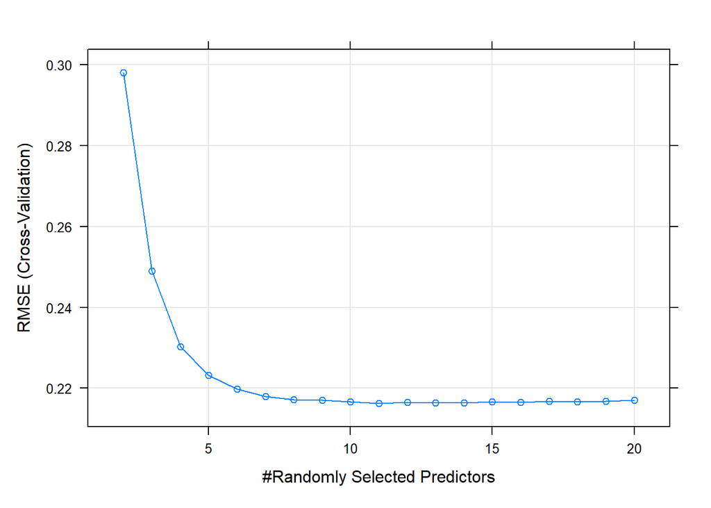

```r
plot(model1_rf)
```

```r
#best mtry chosen as 11


#looking for best min.node.size for mtry = 11
set.seed(1234)
model2_rf <- train(
  log(price) ~ property_type + whether_old_or_new + freehold_or_leasehold + current_energy_rating + total_floor_area + co2_emissions_potential + energy_consumption_potential + tenure + population + altitude + factor(london_zone) + water_company + average_income + type_of_closest_station + num_tube_lines + num_rail_lines + num_light_rail_lines + distance_to_station + latitude + longitude,
  train_data%>%filter(is.na(population)==FALSE),
  method = "ranger",
  trControl = control,
  metric="RMSE",
  tuneGrid=data.frame(.mtry = 11, .splitrule = "variance", .min.node.size = c(2:15)))
print(model2_rf)
```

```
## Random Forest
##
## 10446 samples
##    20 predictor
##
## No pre-processing
## Resampling: Cross-Validated (5 fold)
## Summary of sample sizes: 8357, 8357, 8357, 8356, 8357
## Resampling results across tuning parameters:
##
##   min.node.size  RMSE       Rsquared   MAE
##    2             0.2150883  0.8470539  0.1509931
##    3             0.2153472  0.8467032  0.1511575
##    4             0.2155584  0.8464686  0.1513483
##    5             0.2155678  0.8464370  0.1513428
##    6             0.2156090  0.8465075  0.1512730
##    7             0.2154147  0.8468463  0.1512028
##    8             0.2158319  0.8462791  0.1515375
##    9             0.2160732  0.8460027  0.1517482
##   10             0.2164381  0.8455297  0.1520559
##   11             0.2167092  0.8452465  0.1520764
##   12             0.2167407  0.8453086  0.1521423
##   13             0.2172777  0.8446399  0.1525176
##   14             0.2174353  0.8445038  0.1526619
##   15             0.2175407  0.8444710  0.1527357
##
## Tuning parameter 'mtry' was held constant at a value of 11
## Tuning
##  parameter 'splitrule' was held constant at a value of variance
## RMSE was used to select the optimal model using the smallest value.
## The final values used for the model were mtry = 11, splitrule = variance
##  and min.node.size = 2.
```

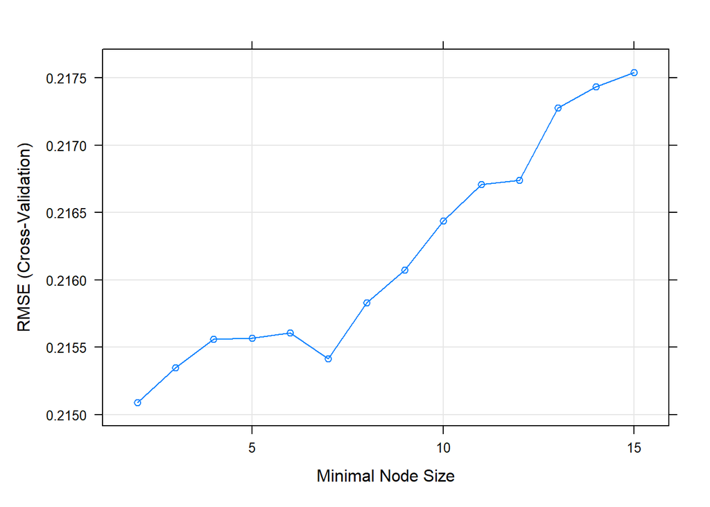

```r
plot(model2_rf)
```

```r
#best min node size chosen as 2


#checking if other splitrules deliver better results than the default (variance)
set.seed(1234)
model3_rf<-train(
  log(price) ~ property_type + whether_old_or_new + freehold_or_leasehold + current_energy_rating + total_floor_area + co2_emissions_potential + energy_consumption_potential + tenure + population + altitude + factor(london_zone) + water_company + average_income + type_of_closest_station + num_tube_lines + num_rail_lines + num_light_rail_lines + distance_to_station + latitude + longitude,
  train_data%>%filter(is.na(population)==FALSE),
  method = "ranger",
  trControl = control,
  metric="RMSE",
  tuneGrid=data.frame(.mtry = 11, .splitrule = c("variance", "extratrees", "maxstat"), .min.node.size = 2),
  importance = 'permutation')
print(model3_rf)
```

```
## Random Forest
##
## 10446 samples
##    20 predictor
##
## No pre-processing
## Resampling: Cross-Validated (5 fold)
## Summary of sample sizes: 8357, 8357, 8357, 8356, 8357
## Resampling results across tuning parameters:
##
##   splitrule   RMSE       Rsquared   MAE
##   extratrees  0.2166856  0.8467436  0.1540523
##   maxstat     0.2315808  0.8343454  0.1635040
##   variance    0.2150983  0.8470335  0.1508725
##
## Tuning parameter 'mtry' was held constant at a value of 11
## Tuning
##  parameter 'min.node.size' was held constant at a value of 2
## RMSE was used to select the optimal model using the smallest value.
## The final values used for the model were mtry = 11, splitrule = variance
##  and min.node.size = 2.
```

```r
#variance seems to be the splitrule that delivers the best result
#model3_rf: RMSE=0.2150983, R2=0.8470335, splitrule=variance, mtry=11, min.node.size=2

varImp(model3_rf)
```

```
## ranger variable importance
##
##   only 20 most important variables shown (out of 36)
##
##                                    Overall
## total_floor_area                   100.000
## longitude                           26.532
## freehold_or_leaseholdL              20.128
## average_income                      19.856
## property_typeF                      16.565
## latitude                            16.554
## co2_emissions_potential             15.161
## factor(london_zone)2                14.584
## water_companyThames Water           10.660
## energy_consumption_potential         9.247
## altitude                             7.252
## num_tube_lines                       6.327
## type_of_closest_stationtube          4.338
## factor(london_zone)3                 3.252
## distance_to_station                  1.952
## type_of_closest_stationrail          1.758
## property_typeT                       1.729
## factor(london_zone)5                 1.631
## water_companyEssex & Suffolk Water   1.386
## factor(london_zone)4                 1.380
```

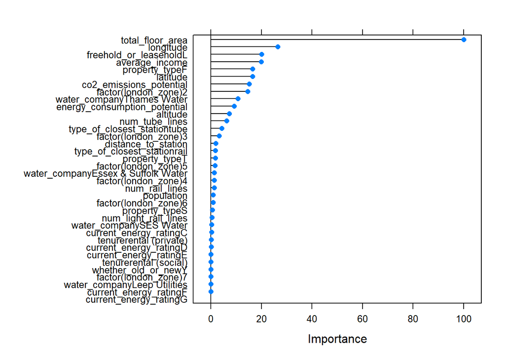

```r
plot(varImp(model3_rf))
```